# Оценка влияния давления и температуры откачиваемого воздуха на производительность водокольцевого вакуумного насоса (ВКВН)

Рассмотрим устройство водокольцевого вакуумного насоса.

[figure not shown]

Схематичная конструкция водокольцевого вакуумного насоса

Внутри корпуса водокольцевого насоса расположен ротор с лопатками, который при вращении отбрасывает воду к стенкам корпуса, тем самым формируя вращающееся водяное кольцо. Ось ротора смещена относительно центра сечения корпуса, в результате чего глубина погружения каждой лопатки ротора в воду за один оборот изменяется от минимального (внизу) до максимального (вверху).

В торцевой стенке сделаны два отверстия, которые соединяют пространство ротора с изолированными друг от друга полостями входного и выходного патрубка соответственно.

Рассмотрим что происходит с пространством между двумя лопатками во время вращения ротора. При нахождении лопаток в верхнем положении их степень погружения в воду максимальна и пространство между ними полностью заполнено водой. По мере вращения ротора против часовой стрелки степень погружения лопаток уменьшается, вода "отступает" и возникает незаполненная водой разрежённая область, куда через входной патрубок поступает откачиваемый воздух.

В области сжатия происходит обратный процесс - по мере вращения объём незаполненного водой пространства уменьшается и воздух выталкивается в полость выходного патрубка.

Принцип действия ВКВН аналогичен принципу действия поршневого насоса: на первом шаге создаётся область разрежения, в которую поступает откачиваемая среда, на втором - среда выталкивается в выходной канал.

На представленном выше рисунке толщина водяного слоя сверху и снизу почему-то показана разной. Такое возможно только в том случае, если скорость воды в рассматриваемых сечениях разная, либо отличны величины объёмного расхода. Скорее всего это просто неточность.

Рабочей жидкостью в ВКВН является вода, которая контактирует с откачиваемым воздухом. Если воздух имеет относительную влажность менее 100% (водяной пар в воздухе не находится в состоянии насыщения), то при его контакте с поверхностью воды вода начинает испаряться. Испаряющаяся вода поступает в область разрежения, заполняя её рабочий объём и, как следствие, снижая производительность ВКВН. Примем что температура рабочей воды в ВКВН выше температуры откачиваемого воздуха (испарение воды происходит за счёт теплоты, отдаваемой водой) и что температура воздуха при контакте его с водой остаётся постоянной (вода не нагревает воздух).

Чем выше температура откачиваемого воздуха и чем ниже его относительная влажность тем большее количество испарившейся воды он может в себя вобрать. Относительная влажность воздуха определяется по формуле $$RH = p_{пар} / p_{нас}$$ где $p_{пар}$ - парциальное давление пара, $p_{нас}$ - давление насыщенного водяного пара (зависит от температуры).

Расчёты будем проводить с использованием модуля `wetairprops` (см. [1])

```python
import numpy as np
from wetairprops import calc_p_s
```

```python
ts_s = np.linspace(0, 60)  # температура влажного воздуха
ps_s = np.array([calc_p_s(t) for t in ts_s]) # давление насыщенного водяного пара
```

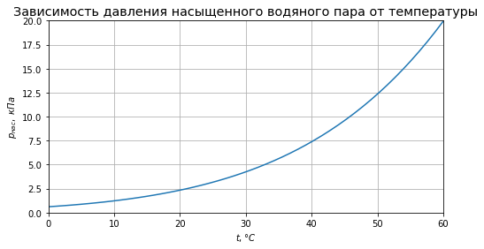

```python
import matplotlib.pyplot as plt
fig, ax = plt.subplots(figsize = (8, 4))
plt.rcParams['font.size'] = 12
ax.set_title("Зависимость давления насыщенного водяного пара от температуры");
ax.set_ylabel('$p_{нас},\ кПа$');
ax.set_xlabel('$t, \degree C$'); ax.plot(ts_s, ps_s/1000); ax.grid();
ax.set_xlim(0., 60); ax.set_ylim(0., 20);
```

При откачке воздуха из герметичной ёмкости давление воздуха в ёмкости и на всасе ВКВН снижается, пропорционально снижению давления воздуха снижается и парциальное давление водяного пара, в то время как давление насыщенного водяного пара остаётся неизменным (т.к. оно зависит только от температуры). Это означает, что при при уменьшении давления откачиваемого воздуха относительная влажность воздуха снижается, что увеличивает его потенциальную влагоёмкость.

```python
p_0 = 101325  # начальное давление откачиваемого воздуха, Па
p_кон = 25e3  # конечное давление откачиваемого воздуха, Па
```

Алгоритм расчёта изменения производительности ВКВН описан в нижеприведённой функции.

```python
from wetairprops import calc_d, calc_dens_d
def calc_dv(t_0 = 15, RH_0 = 0.6, p_0 = 101325, RH_кон = 1., p_кон = 25000):
    """
    Определение уменьшения производительности ВКВН из-за испарения рабочей воды
    t_0: температура откачиваемого воздуха, C
    RH_0: относительная влажность откачиваемого воздуха, доли
    p_0: начальное давление откачиваемого воздуха, Па
    RH_кон: относительная влажность воздуха после контакта с рабочей водой ВКВН, доли
    p_кон: целевое значение давления, Па
    """
    # Влагосодержание откачиваемого воздуха
    d_0 = calc_d(t_0, RH_0, p_0)
    # Плотность откачиваемого воздуха при давлении p_0
    den_0 = calc_dens_d(t_0, d_0, p_0)
    # Плотность откачиваемого воздуха при давлении p_кон
    den_0_кон = den_0 * p_кон / p_0
    # Удельный объём откачиваемого воздуха при давлении p_кон,
    # данная величина пропорциональна рабочему объёму ВКВН
    v_0_кон = 1 / den_0_кон
    # Влагосодержание воздуха при давлении p_кон с учётом дополнительного
    # водяного пара от испарившейся рабочей воды
    d_кон = calc_d(t_0, RH_кон, p_кон)
    # Плотность воздуха при давлении p_кон с учётом испарившейся воды
    den_кон = calc_dens_d(t_0, d_кон, p_кон)
    # Удельный объём воздуха при давлении p_кон с учётом поступившего
    # в воздух дополнительного пара
    v_кон = (1 + (d_кон - d_0) / 1000) / den_кон
    # Изменение рабочего объёма ВКВН за счёт вытеснения откачиваемого
    # воздуха водяным паром от испарившейся рабочей воды, доли
    dv = (v_0_кон - v_кон) / v_0_кон
    return dv
```

Построим графики, показывающие зависимость производжительности ВКВН ($\delta V$, %) от:

1. Давления на всасе ВКВН $p$;
2. Температуры откачиваемого воздуха $t_0$;
3. Начальной относительной влажности откачиваемого воздуха $RH_0$;
4. Относительной влажности откачиваемого воздуха на всасе насоса $RH_{кон}$ при котрой испарение воды прекращается.

```python
ts_0 = np.array([5, 15, 25, 35])  # температура откачиваемого воздуха
RHs_0 = np.array([40, 60, 80, 100])  # относительная влажность откачиваемого воздуха
#RHs_кон = np.array([20, 40, 60, 80, 100-1e-10])  # относительная влажность воздуха в ВКВН
RHs_кон = np.array([20, 40, 60, 80, 100])  # относительная влажность воздуха в ВКВН
```

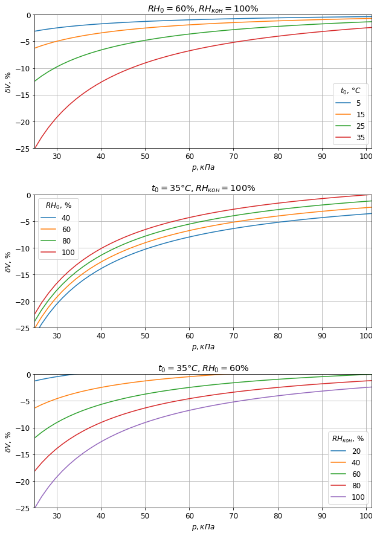

```python
fig, axes = plt.subplots(3, 1, figsize = (10, 15))
plt.subplots_adjust(wspace=0, hspace=0.35)
ps = np.linspace(p_кон, p_0)
for ax in axes:
    ax.set_ylabel('$\delta V,\,\%$');
    ax.set_xlabel('$p, кПа$');  ax.grid();
    ax.set_xlim(p_кон/1e3, p_0/1e3);
    ax.set_ylim(-25, 0);
data = np.zeros((len(ps), len(ts_0)));
for i, t in enumerate(ts_0):
    axes[0].plot(ps/1e3, [calc_dv(t, p_кон = p)*100 for p in ps], label = t);
axes[0].legend(title = '$t_0,\,\degree C$')
axes[0].set_title('$RH_0 = 60 \%, RH_{кон} = 100 \% $');
for i, RH in enumerate(RHs_0):
    axes[1].plot(ps/1e3, [calc_dv(35, RH_0 = RH/100, p_кон = p)*100 for p in ps], label = RH);
axes[1].legend(title = '$RH_0,\,\%$')
axes[1].set_title('$t_0 = 35 \degree C, RH_{кон} = 100 \% $');
for i, RH in enumerate(RHs_кон):
    axes[2].plot(ps/1e3, [calc_dv(t_0 = 35, p_кон = p, RH_кон = RH/100)*100 for p in ps],
                 label = int(round(RH, 0)));
axes[2].legend(title = '$RH_{кон},\,\%$');
axes[2].set_title('$t_0 = 35 \degree C, RH_{0} = 60 \% $');
```

Производительность насоса снижает только поступление пара в область разрежения. После того как пространство между лопатками и содержащийся в нём воздух покинули область разрежения процессы, происходящие в этом пространстве, уже не влияют на производительность ВКВН.

Определим время в течение которого лопатка насоса находится в области разрежения. При оборотах ротора ВКВН 750 об/мин и длине области разрежения в 1/4 длины окружности время нахождения лопатки (и каждой частички откачиваемого воздуха) в области разрежения составит 60 / 750 / 4 = 0,02 секунды.

С учётом того что с водой контактирует только часть откачиваемого воздуха и длительность контакта непродолжительная, можно предположить, что производительность ВКВН при понижении давления воздуха на его всасе если и снижается, то незначительно.

Исключение составляет случай, когда давление воздуха на всасе ВКВН становится равным или меньшим давления закипания воды, соответствующего температуре рабочей воды ВКВН (см. график **Зависимость давления насыщенного водяного пара от температуры**). В этом случае область разрежения заполнится водяным паром от испарившейся рабочей воды ВКВН, и насос не сможет выполнять свою функцию.

### Ссылки

1. [Модуль для расчёта свойств влажного воздуха](https://medsv.github.io/dzen/0048/wetairprops.html)
2. [Моделирование процесса откачки воздуха из ёмкости](https://medsv.github.io/dzen/0044/LRVP.html)

[Инженерные расчёты на Python](https://zen.yandex.ru/id/5f33dcd5554adc5b33aaee83), С.В. Медведев, 2020-2023  
[Использование Python и Jupyter Notebook для инженерных расчётов](https://medsv.github.io/), С.В. Медведев, 2020-2023